# R Notebook

## Cell line gene expression data, input and manipulate as in Module 1

```r
load(file.path(data_dir, "pson_expr_tpm_df.RData"))
```

```r
#How do you see what is included in this df? Run the command.
```

```r
#What are the sample names in pson_expr_tpm_df?
#How are genes identified?
```

```r
#Andrew taught us many ways to inspect the data. Try this one.
View(pson_expr_tpm_df)
```

As you learned, the gene IDs are not very informative — they come from a database called ENSEMBL. More commonly, we would use the Hugo gene symbols (https://www.genenames.org/). These are the gene names you are more used to seeing (MYC, BRCA1, etc). We have this information stored in another file.

```r
load(file.path(data_dir, "pson_expr_gene_info.RData"))
```

```r
#head(gene_df)
convert_ENSG_HUGO_df<-gene_df[,c(1,3)]
head(convert_ENSG_HUGO_df)
```

|  | gene_id | symbol |
| --- | --- | --- |
| 1 | ENSG00000000003 | TSPAN6 |
| 2 | ENSG00000000005 | TNMD |
| 3 | ENSG00000000419 | DPM1 |
| 4 | ENSG00000000457 | SCYL3 |
| 5 | ENSG00000000460 | C1orf112 |
| 6 | ENSG00000000938 | FGR |

Recall what the function merge does. Succint and powerful!

```r
pson_expr_tpm_df2 <- merge(x = gene_df, y = pson_expr_tpm_df,
                           by.x = "gene_id", by.y = "gene_id")
pson_expr_tpm_df2[1:5, 1:9] # view a few more columns this time
```

|  | gene_id | entrez | symbol | biotype | description | mRNA_R17 | mRNA_R21 | mRNA_R20 | mRNA_R19 |
| --- | --- | --- | --- | --- | --- | --- | --- | --- | --- |
| 1 | ENSG00000000003 | 7105 | TSPAN6 | protein_coding | tetraspanin 6 [Source:HGNC Symbol;Acc:11858] | 33.56 | 45.10 | 39.42 | 35.61 |
| 2 | ENSG00000000005 | 64102 | TNMD | protein_coding | tenomodulin [Source:HGNC Symbol;Acc:17757] | 0.00 | 0.00 | 0.00 | 0.00 |
| 3 | ENSG00000000419 | 8813 | DPM1 | protein_coding | dolichyl-phosphate mannosyltransferase polypeptide 1, catalytic subunit [Source:HGNC Symbol;Acc:3005] | 169.46 | 129.88 | 132.06 | 113.73 |
| 4 | ENSG00000000457 | 57147 | SCYL3 | protein_coding | SCY1-like 3 (S. cerevisiae) [Source:HGNC Symbol;Acc:19285] | 1.85 | 1.85 | 1.77 | 1.93 |
| 5 | ENSG00000000460 | 55732 | C1orf112 | protein_coding | chromosome 1 open reading frame 112 [Source:HGNC Symbol;Acc:25565] | 5.73 | 11.85 | 10.16 | 9.28 |

```r
pson_tpm_mat <- as.matrix(pson_expr_tpm_df2[, -c(1:5)])
rownames(pson_tpm_mat) <- pson_expr_tpm_df2$symbol
pson_tpm_mat[1:5, 1:5]
```

```
         mRNA_R17 mRNA_R21 mRNA_R20 mRNA_R19 mRNA_R18
TSPAN6      33.56    45.10    39.42    35.61    32.10
TNMD         0.00     0.00     0.00     0.00     0.00
DPM1       169.46   129.88   132.06   113.73   123.37
SCYL3        1.85     1.85     1.77     1.93     2.30
C1orf112     5.73    11.85    10.16     9.28    10.01
```

```r
pson_logtpm_mat <- log2(1 + pson_tpm_mat)
pson_logtpm_mat[1:5, 1:5]
```

```
         mRNA_R17 mRNA_R21 mRNA_R20 mRNA_R19 mRNA_R18
TSPAN6   5.111031 5.526695 5.336997 5.194166 5.048759
TNMD     0.000000 0.000000 0.000000 0.000000 0.000000
DPM1     7.413289 7.032101 7.055933 6.842099 6.958495
SCYL3    1.510962 1.510962 1.469886 1.550901 1.722466
C1orf112 2.750607 3.683696 3.480265 3.361768 3.460743
```

We will us the function “prcomp()” to run the principal component analysis algorithm. “prcomp()” takes a matrix as input where the samples (cell lines) are the rows, and the features (transcript counts) are the columns.

```r
pson_mat<-t(pson_logtpm_mat)
pson_mat<-pson_mat[-8,]
```

As described in our lecture, there are two additional things for us to consider. 1) The data should be mean centered around 0, and 2) the data should be scaled so that the standard deviation for each gene is 1. Our features have the same units, and it is often the case that they are not scaled; this is somewhat subjective. “prcomp()” automatically mean centers the data for us. Scaling is up to us.

```r
PCA_PSON<-prcomp(pson_mat, scale=FALSE)
```

Exciting, right? But now we can get to our exploratory analysis. What goodies does PCA_PSON hold for us?

```r
names(PCA_PSON)
```

```
[1] "sdev"     "rotation" "center"   "scale"    "x"
```

We discussed these in the lecture. To summarize: “sdev”: The standard deviation of the principal components “rotation”: The matrix of feature loadings (weights) “center”: The feature means that prcomp() subtracted from each feature “scale”: The feature standard deviations used in scaling “x”: Coordinates of the cell lines projected onto the principal components

```r
dim(PCA_PSON$sdev)
```

```r
dim(PCA_PSON$rotation)
```

[output not shown]

```r
dim(PCA_PSON$center)
```

```r
dim(PCA_PSON$scale)
```

```r
dim(PCA_PSON$x)
```

[output not shown]

Are these dimensions what you would expect?

```r
PCA_PSON$rotation[1:5, 1:5]
```

```
                    PC1            PC2             PC3            PC4             PC5
TSPAN6    0.00015841576 -0.00461016723  0.005191321375  0.00318000744  0.017295621313
TNMD      0.00002753341  0.00001197326 -0.000002777844 -0.00002525294  0.000001860216
DPM1     -0.00057990117 -0.00131654255  0.007183746775 -0.00060224653 -0.001600114594
SCYL3    -0.00289398920  0.01230555456 -0.001404973716  0.00070945118 -0.002288287137
C1orf112 -0.00288072380  0.00156273245  0.000938190550  0.00168151417  0.002043381890
```

```r
PCA_PSON$x[1:5,1:5]
```

```
               PC1       PC2       PC3         PC4      PC5
mRNA_R17 -39.74973 -76.79247  6.395282  -1.5573725 34.99499
mRNA_R21 -44.31163 -70.45641 16.540568  -5.2920620 50.47853
mRNA_R20 -45.41556 -80.75207  9.007610  -0.0308181 42.11339
mRNA_R19 -42.46163 -73.68480 13.031576  -3.3063448 45.94905
mRNA_R18 -37.95296 -62.22346 19.415076 -10.2662479 43.98570
```

```r
length(PCA_PSON$sdev)
```

```
[1] 62
```

```r
length(PCA_PSON$center)
```

```
[1] 18682
```

```r
length(PCA_PSON$scale)
```

```
[1] 1
```

Check the values out! Why does scale have length 1?

Has PCA reduced the dimensionality of our data? Let’s examine the importance of the principal components by ploting the percentage of variance explained.

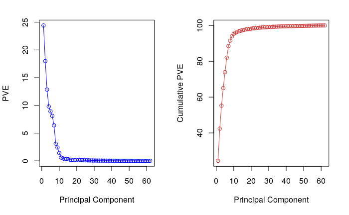

```r
pve<-100*PCA_PSON$sdev^2/sum(PCA_PSON$sdev^2)
par(mfrow=c(1,2))
plot(pve, type="o", ylab="PVE", xlab="Principal Component", col="blue")
plot(cumsum(pve), type="o", ylab="Cumulative PVE", xlab="Principal Component", col="brown3")
```

The first two PCs account for a lot of the variance, > 40%. The first 10 PCs account for almost all of the variance. Let’s see if the first two PCs, PC1 and PC2, reveal any patterns in our data.

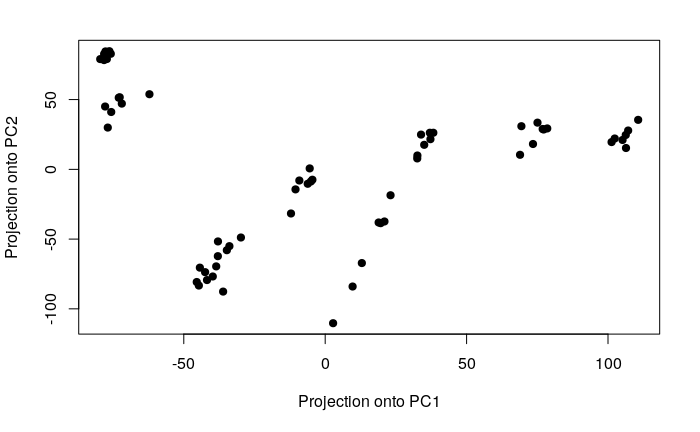

```r
plot(PCA_PSON$x[,1:2], pch=19, xlab="Projection onto PC1", ylab="Projection onto PC2")
```

Each point gives the coordinates of a sample/cell line in PC space. It’s a nice pattern with some potential. Does is have meaning for our data set? Let’s color the points by cell line type and diagnosis.

```r
load(file.path(data_dir, "pson_motility_tidy_df.RData"))
cell_speeds_df <- subset(pson_motil_tidy_df, summary_metric == "speed_um_hr")
names(cell_speeds_df)
```

```
 [1] "id_motil"                      "summary_metric"                "average_value"
 [4] "standard_deviation"            "standard_error"                "total_number_of_cells_tracked"
 [7] "sample"                        "id_expr"                       "diagnosis"
[10] "cellType"                      "catalogNumber"                 "cellLine"
[13] "experimentalCondition"         "stiffness"                     "stiffness_units"
[16] "surface"                       "laminate"                      "organ"
[19] "tumorType"                     "stiffness_norm"                "average_value_scaled"
```

We will color by “cellLine” and “diagnosis”, and it is possible to explore other relationships as well.

Here is a simple function for coloring points by type:

```r
csbc_Color=function(vec){

nn<-length(unique(vec))

csbc_cols=rainbow(nn,start=0,end=max(1,nn-1)/nn)

return(csbc_cols[as.numeric(as.factor(vec))])
}
```

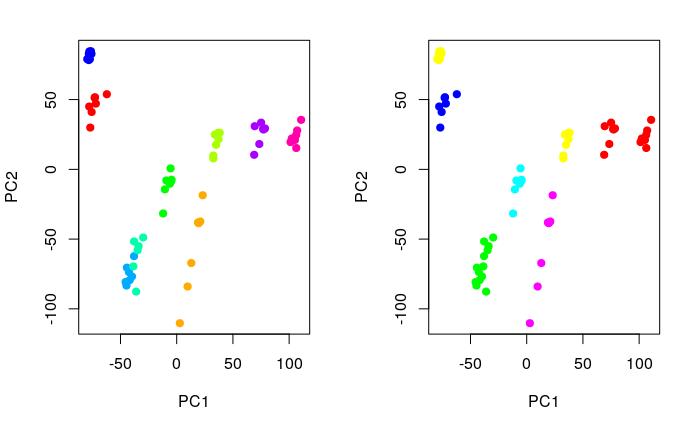

```r
par(mfrow=c(1,2))
plot(PCA_PSON$x[,c(1,2)],col=csbc_Color(cell_speeds_df$cellLine), pch=19)
plot(PCA_PSON$x[,c(1,2)],col=csbc_Color(cell_speeds_df$diagnosis), pch=19)
```

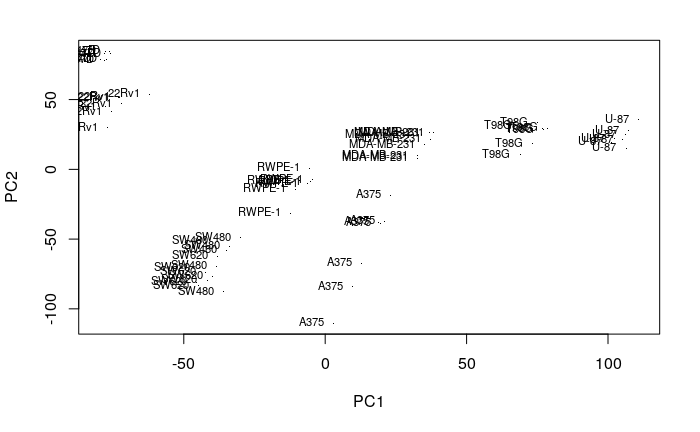

```r
plot(PCA_PSON$x[,c(1,2)],pch=".")
text(PCA_PSON$x[,c(1,2)],labels=cell_speeds_df$cellLine,pos=2,cex=0.7)
```

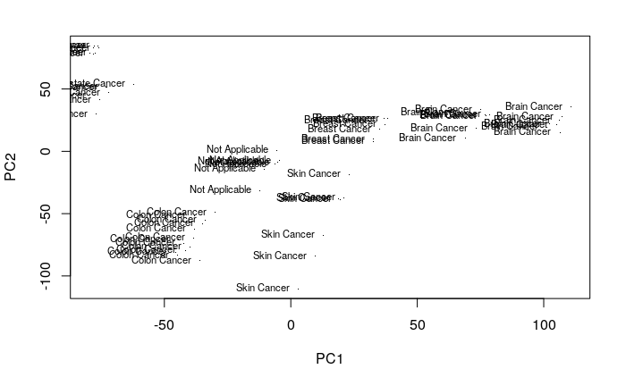

```r
plot(PCA_PSON$x[,c(1,2)],pch=".")
text(PCA_PSON$x[,c(1,2)],labels=cell_speeds_df$diagnosis,pos=2,cex=0.7)
```

We can perform additional principal components analyses on cell line specific data.